# Econ 320: Python Assignment 3

## Package setup

```
/Users/plopezd/Dropbox/Emory Courses/Lab320/Assignments
```

# Question 1

The dataset *ps2q1.dta* contains data on 177 chief executive officers and can be used to examine the effects of firm performance on CEO salary.

i. Estimate a model relating the CEO's annual salary, the dependent variable, to firm sales, the independent variable.

$$salary_i= \beta_0 + \beta_1sales_i +u_i$$

What is your estimate of the intercept and the slope? Don't forget the units, which you can find using the "describe" command. Interpret these estimates, providing an intuitive description that a person who has not taken econometrics can understand. Does your result make economic sense?

```
<class 'pandas.core.frame.DataFrame'>
Int64Index: 177 entries, 0 to 176
Data columns (total 12 columns):
 #   Column    Non-Null Count  Dtype
---  ------    --------------  -----
 0   salary    177 non-null    int16
 1   age       177 non-null    int8
 2   college   177 non-null    int8
 3   grad      177 non-null    int8
 4   comten    177 non-null    int8
 5   ceoten    177 non-null    int8
 6   sales     177 non-null    float32
 7   profits   177 non-null    int16
 8   mktval    177 non-null    float32
 9   comtensq  177 non-null    int16
 10  ceotensq  177 non-null    int16
 11  profmarg  177 non-null    float32
dtypes: float32(3), int16(4), int8(5)
memory usage: 5.7 KB
```

OLS Regression Results

| Dep. Variable: | salary | R-squared: | 0.438 |
| --- | --- | --- | --- |
| Model: | OLS | Adj. R-squared: | 0.435 |
| Method: | Least Squares | F-statistic: | 136.6 |
| Date: | Wed, 16 Oct 2024 | Prob (F-statistic): | 1.08e-23 |
| Time: | 16:32:00 | Log-Likelihood: | -1456.2 |
| No. Observations: | 177 | AIC: | 2916. |
| Df Residuals: | 175 | BIC: | 2923. |
| Df Model: | 1 |  |  |
| Covariance Type: | nonrobust |  |  |

|  | coef | std err | t | P>\|t\| | [0.025 | 0.975] |
| --- | --- | --- | --- | --- | --- | --- |
| Intercept | 474.2893 | 79.154 | 5.992 | 0.000 | 318.071 | 630.508 |
| sales | 0.1317 | 0.011 | 11.687 | 0.000 | 0.109 | 0.154 |

| Omnibus: | 187.510 | Durbin-Watson: | 2.086 |
| --- | --- | --- | --- |
| Prob(Omnibus): | 0.000 | Jarque-Bera (JB): | 8601.497 |
| Skew: | 3.774 | Prob(JB): | 0.00 |
| Kurtosis: | 36.307 | Cond. No. | 8.12e+03 |

Notes:  
[1] Standard Errors assume that the covariance matrix of the errors is correctly specified.  
[2] The condition number is large, 8.12e+03. This might indicate that there are  
strong multicollinearity or other numerical problems.

ii. Calculate the mean of $salary$ and $sales$. Use these values to prove that the predicted regression line estimated in regression (1) goes through the means of $salary$ and $sales$.

|  | salary | sales |
| --- | --- | --- |
| count | 177.000 | 177.000 |
| mean | 939.192 | 3529.463 |
| std | 1211.342 | 6088.654 |
| min | 100.000 | 29.000 |
| max | 15000.000 | 51300.000 |

```
Estimated salary for mean sales 939.192
Mean of salaries 939.1921
Therefore averages of salaries and sales are in the estimated line
```

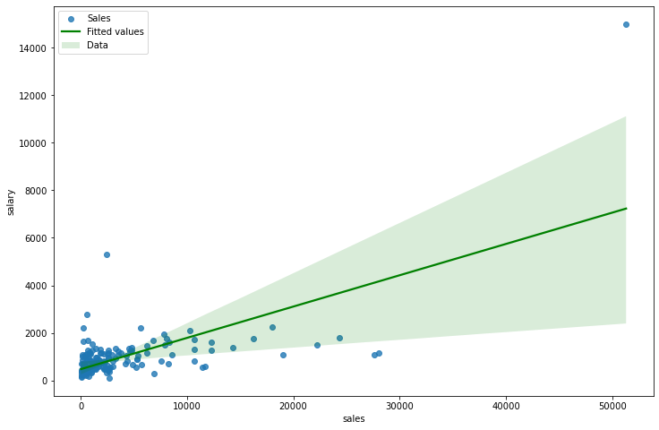

It appears as sales increase the marginal change to CEO salaries is smaller than predicted by this OLS model. This may be the result of an outlier with \$15,000 salary with \\$50,000 in sales.

iii. The data entry expert contacts you very concerned about the data they gave you. They realized there was a typo. Replace the value of salary to be 2500 if salary is equal to 15000. Estimate regression (1) with this change. Save the predicted values of salary (). Show a graph with the scatter plot of salary and sales and the predicted regression line of question 1.1 and question 1.4. Discuss these results.

OLS Regression Results

| Dep. Variable: | salary | R-squared: | 0.170 |
| --- | --- | --- | --- |
| Model: | OLS | Adj. R-squared: | 0.165 |
| Method: | Least Squares | F-statistic: | 35.79 |
| Date: | Wed, 16 Oct 2024 | Prob (F-statistic): | 1.21e-08 |
| Time: | 16:32:02 | Log-Likelihood: | -1364.7 |
| No. Observations: | 177 | AIC: | 2733. |
| Df Residuals: | 175 | BIC: | 2740. |
| Df Model: | 1 |  |  |
| Covariance Type: | nonrobust |  |  |

|  | coef | std err | t | P>\|t\| | [0.025 | 0.975] |
| --- | --- | --- | --- | --- | --- | --- |
| Intercept | 726.6835 | 47.190 | 15.399 | 0.000 | 633.548 | 819.819 |
| sales | 0.0402 | 0.007 | 5.983 | 0.000 | 0.027 | 0.053 |

| Omnibus: | 181.219 | Durbin-Watson: | 2.190 |
| --- | --- | --- | --- |
| Prob(Omnibus): | 0.000 | Jarque-Bera (JB): | 5371.839 |
| Skew: | 3.774 | Prob(JB): | 0.00 |
| Kurtosis: | 28.911 | Cond. No. | 8.12e+03 |

Notes:  
[1] Standard Errors assume that the covariance matrix of the errors is correctly specified.  
[2] The condition number is large, 8.12e+03. This might indicate that there are  
strong multicollinearity or other numerical problems.

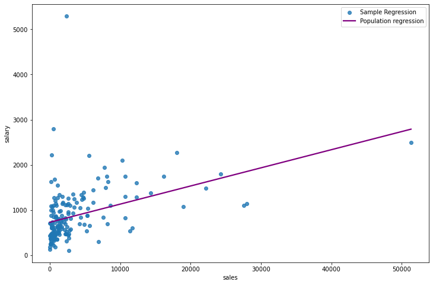

iv. A colleague presented a histogram displaying the distribution of salary and argued that no one could draw any conclusions from a regression using this variable. He correctly points out that regression lines fit through data better when the data is spread across the range of the variable’s possible values. Your colleague wants to use the natural **log of salary** and the natural **log of sales** in the model as this function can help to spread out the values of salary and sales. Create the natural logarithm of salary, lnsalary, and the natural logarithm of sales, lnsales. Show the histograms of salary, lnsalary, sales, and lnsales. Discuss whether you think your colleague’s method of spreading the data worked. Estimate the following model:

$lnsalaryi=\gamma_0+\gamma_1lnsalesi+vi$

Then show the regression plot for this new model

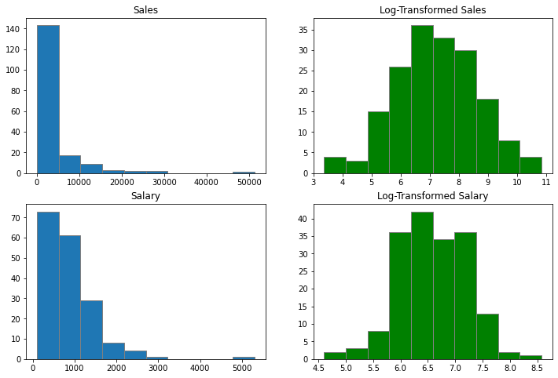

OLS Regression Results

| Dep. Variable: | lnsalary | R-squared: | 0.284 |
| --- | --- | --- | --- |
| Model: | OLS | Adj. R-squared: | 0.280 |
| Method: | Least Squares | F-statistic: | 69.45 |
| Date: | Wed, 16 Oct 2024 | Prob (F-statistic): | 2.22e-14 |
| Time: | 16:25:08 | Log-Likelihood: | -133.09 |
| No. Observations: | 177 | AIC: | 270.2 |
| Df Residuals: | 175 | BIC: | 276.5 |
| Df Model: | 1 |  |  |
| Covariance Type: | nonrobust |  |  |

|  | coef | std err | t | P>\|t\| | [0.025 | 0.975] |
| --- | --- | --- | --- | --- | --- | --- |
| Intercept | 4.9469 | 0.200 | 24.703 | 0.000 | 4.552 | 5.342 |
| lnsales | 0.2264 | 0.027 | 8.333 | 0.000 | 0.173 | 0.280 |

| Omnibus: | 12.470 | Durbin-Watson: | 2.090 |
| --- | --- | --- | --- |
| Prob(Omnibus): | 0.002 | Jarque-Bera (JB): | 33.002 |
| Skew: | 0.060 | Prob(JB): | 6.82e-08 |
| Kurtosis: | 5.112 | Cond. No. | 38.7 |

Notes:  
[1] Standard Errors assume that the covariance matrix of the errors is correctly specified.

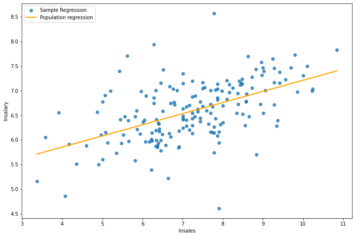

# Question 2

Use the dataset ATTEND for this exercise, and the handouts to work on these questions. Wooldridge data sets here: http://fmwww.bc.edu/ec-p/data/wooldridge/datasets.list.html

i. Generate a table that shows the minimum, maximum, and average values for the following variables in the attend dataset:  
Percent classes attended  
Cumulative GPA prior to term  
ACT score  
Using two different methods. Round off all calculations to 3 decimal points. (Refer to handout)

|  | atndrte | priGPA | ACT |
| --- | --- | --- | --- |
| mean | 81.71 | 2.587 | 22.51 |
| min | 6.25 | 0.857 | 13.00 |
| max | 100.00 | 3.930 | 32.00 |

|  | atndrte | priGPA | ACT |
| --- | --- | --- | --- |
| count | 680.000 | 680.000 | 680.000 |
| mean | 81.710 | 2.587 | 22.510 |
| std | 17.047 | 0.545 | 3.491 |
| min | 6.250 | 0.857 | 13.000 |
| 25% | 75.000 | 2.190 | 20.000 |
| 50% | 87.500 | 2.560 | 22.000 |
| 75% | 93.750 | 2.943 | 25.000 |
| max | 100.000 | 3.930 | 32.000 |

ii. Estimate the following model:

$$atndrte = \beta_0 + \beta_1 priGPA + \beta_2 ACT + u$$

Show results in an stargazer table. (Refer to output presentation handout)

|  | *Dependent variable:atndrte* |
| --- | --- |
|  | (1) |
| ACT | -1.717*** |
|  | (0.169) |
| Intercept | 75.700*** |
|  | (3.884) |
| priGPA | 17.261*** |
|  | (1.083) |
| Observations | 680 |
| R<sup>2</sup> | 0.291 |
| Adjusted R<sup>2</sup> | 0.288 |
| Residual Std. Error | 14.379 (df=677) |
| F Statistic | 138.651*** (df=2; 677) |
| Note: | *p<0.1; **p<0.05; ***p<0.01 |

iii. Calculate and print the average of predicted value of percent classes attended ( $\hat{atndrte}$ ) and the predicted value. Round to 5 decimal points and compare results. (Refer to week 5 module)

> Note that these two are different coding-wise. The first method is the mean of the prediction, and the second is the prediction of the mean

```
Model1
 Average predicted attendance rate is
 mean of yhat= 81.70956
Model1
 Predicted attendance rate for average GPA and ACT is
 yhat of mean x=  81.70956
```

iv. What is the predicted `atndrte` if `priGPA`= 3.65 and `ACT`= 20? What is the predicted difference in attendance rates between this and the the average $\hat{atndrte}$ above? (Refer to week 3 and 4 module)
In this case, do not use the `.predict()` function for your code. Instead, retrieve the coeffients and calculate the equation.
$$atndrte = \hat\beta_0 + \hat\beta_1 3.65 + \hat\beta_2 20 + u$$

```
yhat =  104.371
Difference =  22.661
```

v. Run two more models: one only for freshmen and another only for sophomores. Save the results in objects `mfre` and `msoph` respectively  
*Hint: the data argument now has a restriction*  
Freshmen : `attend['frosh']==1`  
Sophomores : `attend['soph']==1`

vi. Show your results in a table:

Create one table comparing the parameters from the three models and another table comparing $R^2$ and the number of observations. Label the results with all students "All", data with just freshmen "Freshmen", and data with just sophomores "Sophomore". Round all values to 4 decimal places. (Refer to week 3 module)

The table below compares $\beta's$

|  | All | Freshmen | Soph |
| --- | --- | --- | --- |
| Intercept | 75.700 | 76.507 | 74.887 |
| priGPA | 17.261 | 16.062 | 18.869 |
| ACT | -1.717 | -1.487 | -1.898 |

The table below compares the $R^2$ and observations for the models estimated. $\textbf{HINT:}$ If you are stuck, look up how to use the index options.

|  | All | Freshmen | Soph |
| --- | --- | --- | --- |
| R2 | 0.291 | 0.286 | 0.320 |
| obs | 680.000 | 158.000 | 392.000 |

vii. Calculate the correlation between the residuals and the `priGPA` for the first model. This is similar to how we showed that mean of residuals is equal to zero (Refer to week 3 and module).

```
Corr GPA and residuals:
 0.0
```

vi. Present all results form the three models in an stargazer table Change the order of the covariates and add name to the columns

|  | *Dependent variable:atndrte* |  |  |
| --- | --- | --- | --- |
|  | All | Freshmen | Sophomore |
|  | (1) | (2) | (3) |
| Intercept | 75.700*** | 76.507*** | 74.887*** |
|  | (3.884) | (8.679) | (5.113) |
| priGPA | 17.261*** | 16.062*** | 18.869*** |
|  | (1.083) | (2.362) | (1.440) |
| ACT | -1.717*** | -1.487*** | -1.898*** |
|  | (0.169) | (0.331) | (0.227) |
| Observations | 680 | 158 | 392 |
| R<sup>2</sup> | 0.291 | 0.286 | 0.320 |
| Adjusted R<sup>2</sup> | 0.288 | 0.277 | 0.316 |
| Residual Std. Error | 14.379 (df=677) | 14.029 (df=155) | 14.157 (df=389) |
| F Statistic | 138.651*** (df=2; 677) | 31.106*** (df=2; 155) | 91.510*** (df=2; 389) |
| Note: | *p<0.1; **p<0.05; ***p<0.01 |  |  |

# From Computer Exercise 10

Use the data in Wooldridge's HTV to answer this question. The data set includes information on wages, education, parents’ education, and several other variables for 1,230 working men in 1991.

i. Investigate some descriptive statistics

- What is the range of the `educ` variable in the sample?

```
count    1230.000000
mean       13.037398
std         2.354346
min         6.000000
25%        12.000000
50%        12.000000
75%        15.000000
max        20.000000
Name: educ, dtype: float64
```

- What percentage of men completed twelveth grade but no higher grade?

  > Hint: use a logical expression and calculate the mean
- Do the men or their parents have, on average, higher levels of education?

```
Percentage of men with HS=  0.416
```

|  | Averages |
| --- | --- |
| educ | 13.037 |
| motheduc | 12.178 |
| fatheduc | 12.447 |

ii. Estimate the regression model $$educ = \beta_0 + \beta_1motheduc + \beta_2fatheduc + u$$ by OLS and report the results in the usual form.

How much sample variation in `educ` is explained by parents’ education? Think about the interpretation of the coefficient on `motheduc`.

OLS Regression Results

| Dep. Variable: | educ | R-squared: | 0.249 |
| --- | --- | --- | --- |
| Model: | OLS | Adj. R-squared: | 0.248 |
| Method: | Least Squares | F-statistic: | 203.7 |
| Date: | Wed, 16 Oct 2024 | Prob (F-statistic): | 4.13e-77 |
| Time: | 16:49:21 | Log-Likelihood: | -2621.7 |
| No. Observations: | 1230 | AIC: | 5249. |
| Df Residuals: | 1227 | BIC: | 5265. |
| Df Model: | 2 |  |  |
| Covariance Type: | nonrobust |  |  |

|  | coef | std err | t | P>\|t\| | [0.025 | 0.975] |
| --- | --- | --- | --- | --- | --- | --- |
| Intercept | 6.9644 | 0.320 | 21.776 | 0.000 | 6.337 | 7.592 |
| motheduc | 0.3042 | 0.032 | 9.528 | 0.000 | 0.242 | 0.367 |
| fatheduc | 0.1903 | 0.022 | 8.539 | 0.000 | 0.147 | 0.234 |

| Omnibus: | 60.519 | Durbin-Watson: | 1.748 |
| --- | --- | --- | --- |
| Prob(Omnibus): | 0.000 | Jarque-Bera (JB): | 82.103 |
| Skew: | 0.455 | Prob(JB): | 1.48e-18 |
| Kurtosis: | 3.879 | Cond. No. | 98.0 |

Notes:  
[1] Standard Errors assume that the covariance matrix of the errors is correctly specified.

iii. Add the variable `abil` (a measure of cognitive ability) to the regression from part (ii), and report the results in equation form. Does “ability” help to explain variations in education, even after controlling for parents’ education? Explain.

OLS Regression Results

| Dep. Variable: | educ | R-squared: | 0.428 |
| --- | --- | --- | --- |
| Model: | OLS | Adj. R-squared: | 0.426 |
| Method: | Least Squares | F-statistic: | 305.2 |
| Date: | Wed, 16 Oct 2024 | Prob (F-statistic): | 5.95e-148 |
| Time: | 16:49:23 | Log-Likelihood: | -2455.0 |
| No. Observations: | 1230 | AIC: | 4918. |
| Df Residuals: | 1226 | BIC: | 4938. |
| Df Model: | 3 |  |  |
| Covariance Type: | nonrobust |  |  |

|  | coef | std err | t | P>\|t\| | [0.025 | 0.975] |
| --- | --- | --- | --- | --- | --- | --- |
| Intercept | 8.4487 | 0.290 | 29.180 | 0.000 | 7.881 | 9.017 |
| motheduc | 0.1891 | 0.029 | 6.635 | 0.000 | 0.133 | 0.245 |
| fatheduc | 0.1111 | 0.020 | 5.586 | 0.000 | 0.072 | 0.150 |
| abil | 0.5025 | 0.026 | 19.538 | 0.000 | 0.452 | 0.553 |

| Omnibus: | 52.055 | Durbin-Watson: | 1.821 |
| --- | --- | --- | --- |
| Prob(Omnibus): | 0.000 | Jarque-Bera (JB): | 61.086 |
| Skew: | 0.465 | Prob(JB): | 5.44e-14 |
| Kurtosis: | 3.570 | Cond. No. | 102. |

Notes:  
[1] Standard Errors assume that the covariance matrix of the errors is correctly specified.

iv. Now estimate an equation where `abil` appears in quadratic form

OLS Regression Results

| Dep. Variable: | educ | R-squared: | 0.444 |
| --- | --- | --- | --- |
| Model: | OLS | Adj. R-squared: | 0.443 |
| Method: | Least Squares | F-statistic: | 244.9 |
| Date: | Wed, 16 Oct 2024 | Prob (F-statistic): | 1.34e-154 |
| Time: | 16:49:31 | Log-Likelihood: | -2436.6 |
| No. Observations: | 1230 | AIC: | 4883. |
| Df Residuals: | 1225 | BIC: | 4909. |
| Df Model: | 4 |  |  |
| Covariance Type: | nonrobust |  |  |

|  | coef | std err | t | P>\|t\| | [0.025 | 0.975] |
| --- | --- | --- | --- | --- | --- | --- |
| Intercept | 8.2402 | 0.287 | 28.671 | 0.000 | 7.676 | 8.804 |
| motheduc | 0.1901 | 0.028 | 6.767 | 0.000 | 0.135 | 0.245 |
| fatheduc | 0.1089 | 0.020 | 5.558 | 0.000 | 0.070 | 0.147 |
| abil | 0.4015 | 0.030 | 13.255 | 0.000 | 0.342 | 0.461 |
| np.power(abil, 2) | 0.0506 | 0.008 | 6.093 | 0.000 | 0.034 | 0.067 |

| Omnibus: | 45.933 | Durbin-Watson: | 1.820 |
| --- | --- | --- | --- |
| Prob(Omnibus): | 0.000 | Jarque-Bera (JB): | 56.769 |
| Skew: | 0.404 | Prob(JB): | 4.71e-13 |
| Kurtosis: | 3.674 | Cond. No. | 115. |

Notes:  
[1] Standard Errors assume that the covariance matrix of the errors is correctly specified.

v. Use the estimates in part (iv) to graph the relationship between the predicted `education` and `abil`. Set `motheduc` and `fatheduc` at their average values in the sample, 12.18 and 12.45, respectively. See handout for more. (Refer to week 4 module)

```
Intercept            8.240226
motheduc             0.190126
fatheduc             0.108939
abil                 0.401462
np.power(abil, 2)    0.050599
dtype: float64
```

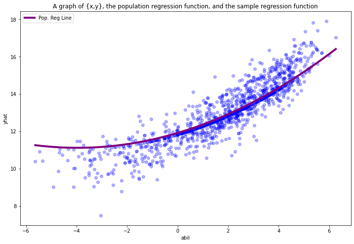

ECON320 Python Programming Laboratory

Professor *Paloma Lopez de mesa Moyano*

*paloma.moyano@emory.edu*

Department of Economics

Emory University

# Econ 320: Python Assignment 3

## Package setup

```
/Users/plopezd/Dropbox/Emory Courses/Lab320/Assignments
```

# Question 1

The dataset *ps2q1.dta* contains data on 177 chief executive officers and can be used to examine the effects of firm performance on CEO salary.

i. Estimate a model relating the CEO's annual salary, the dependent variable, to firm sales, the independent variable.

$$salary_i= \beta_0 + \beta_1sales_i +u_i$$

What is your estimate of the intercept and the slope? Don't forget the units, which you can find using the "describe" command. Interpret these estimates, providing an intuitive description that a person who has not taken econometrics can understand. Does your result make economic sense?

```
<class 'pandas.core.frame.DataFrame'>
Int64Index: 177 entries, 0 to 176
Data columns (total 12 columns):
 #   Column    Non-Null Count  Dtype
---  ------    --------------  -----
 0   salary    177 non-null    int16
 1   age       177 non-null    int8
 2   college   177 non-null    int8
 3   grad      177 non-null    int8
 4   comten    177 non-null    int8
 5   ceoten    177 non-null    int8
 6   sales     177 non-null    float32
 7   profits   177 non-null    int16
 8   mktval    177 non-null    float32
 9   comtensq  177 non-null    int16
 10  ceotensq  177 non-null    int16
 11  profmarg  177 non-null    float32
dtypes: float32(3), int16(4), int8(5)
memory usage: 5.7 KB
```

OLS Regression Results

| Dep. Variable: | salary | R-squared: | 0.438 |
| --- | --- | --- | --- |
| Model: | OLS | Adj. R-squared: | 0.435 |
| Method: | Least Squares | F-statistic: | 136.6 |
| Date: | Wed, 16 Oct 2024 | Prob (F-statistic): | 1.08e-23 |
| Time: | 16:32:00 | Log-Likelihood: | -1456.2 |
| No. Observations: | 177 | AIC: | 2916. |
| Df Residuals: | 175 | BIC: | 2923. |
| Df Model: | 1 |  |  |
| Covariance Type: | nonrobust |  |  |

|  | coef | std err | t | P>\|t\| | [0.025 | 0.975] |
| --- | --- | --- | --- | --- | --- | --- |
| Intercept | 474.2893 | 79.154 | 5.992 | 0.000 | 318.071 | 630.508 |
| sales | 0.1317 | 0.011 | 11.687 | 0.000 | 0.109 | 0.154 |

| Omnibus: | 187.510 | Durbin-Watson: | 2.086 |
| --- | --- | --- | --- |
| Prob(Omnibus): | 0.000 | Jarque-Bera (JB): | 8601.497 |
| Skew: | 3.774 | Prob(JB): | 0.00 |
| Kurtosis: | 36.307 | Cond. No. | 8.12e+03 |

Notes:  
[1] Standard Errors assume that the covariance matrix of the errors is correctly specified.  
[2] The condition number is large, 8.12e+03. This might indicate that there are  
strong multicollinearity or other numerical problems.

ii. Calculate the mean of $salary$ and $sales$. Use these values to prove that the predicted regression line estimated in regression (1) goes through the means of $salary$ and $sales$.

|  | salary | sales |
| --- | --- | --- |
| count | 177.000 | 177.000 |
| mean | 939.192 | 3529.463 |
| std | 1211.342 | 6088.654 |
| min | 100.000 | 29.000 |
| max | 15000.000 | 51300.000 |

```
Estimated salary for mean sales 939.192
Mean of salaries 939.1921
Therefore averages of salaries and sales are in the estimated line
```

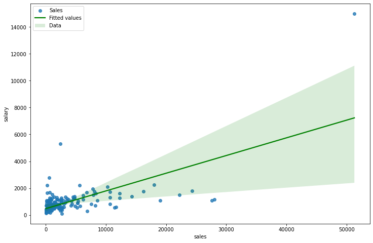

It appears as sales increase the marginal change to CEO salaries is smaller than predicted by this OLS model. This may be the result of an outlier with \$15,000 salary with \\$50,000 in sales.

iii. The data entry expert contacts you very concerned about the data they gave you. They realized there was a typo. Replace the value of salary to be 2500 if salary is equal to 15000. Estimate regression (1) with this change. Save the predicted values of salary (). Show a graph with the scatter plot of salary and sales and the predicted regression line of question 1.1 and question 1.4. Discuss these results.

OLS Regression Results

| Dep. Variable: | salary | R-squared: | 0.170 |
| --- | --- | --- | --- |
| Model: | OLS | Adj. R-squared: | 0.165 |
| Method: | Least Squares | F-statistic: | 35.79 |
| Date: | Wed, 16 Oct 2024 | Prob (F-statistic): | 1.21e-08 |
| Time: | 16:32:02 | Log-Likelihood: | -1364.7 |
| No. Observations: | 177 | AIC: | 2733. |
| Df Residuals: | 175 | BIC: | 2740. |
| Df Model: | 1 |  |  |
| Covariance Type: | nonrobust |  |  |

|  | coef | std err | t | P>\|t\| | [0.025 | 0.975] |
| --- | --- | --- | --- | --- | --- | --- |
| Intercept | 726.6835 | 47.190 | 15.399 | 0.000 | 633.548 | 819.819 |
| sales | 0.0402 | 0.007 | 5.983 | 0.000 | 0.027 | 0.053 |

| Omnibus: | 181.219 | Durbin-Watson: | 2.190 |
| --- | --- | --- | --- |
| Prob(Omnibus): | 0.000 | Jarque-Bera (JB): | 5371.839 |
| Skew: | 3.774 | Prob(JB): | 0.00 |
| Kurtosis: | 28.911 | Cond. No. | 8.12e+03 |

Notes:  
[1] Standard Errors assume that the covariance matrix of the errors is correctly specified.  
[2] The condition number is large, 8.12e+03. This might indicate that there are  
strong multicollinearity or other numerical problems.

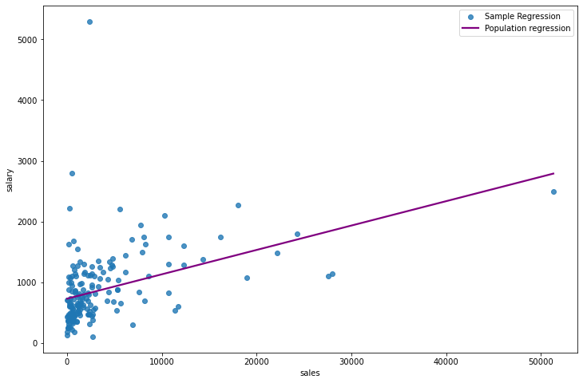

iv. A colleague presented a histogram displaying the distribution of salary and argued that no one could draw any conclusions from a regression using this variable. He correctly points out that regression lines fit through data better when the data is spread across the range of the variable’s possible values. Your colleague wants to use the natural **log of salary** and the natural **log of sales** in the model as this function can help to spread out the values of salary and sales. Create the natural logarithm of salary, lnsalary, and the natural logarithm of sales, lnsales. Show the histograms of salary, lnsalary, sales, and lnsales. Discuss whether you think your colleague’s method of spreading the data worked. Estimate the following model:

$lnsalaryi=\gamma_0+\gamma_1lnsalesi+vi$

Then show the regression plot for this new model

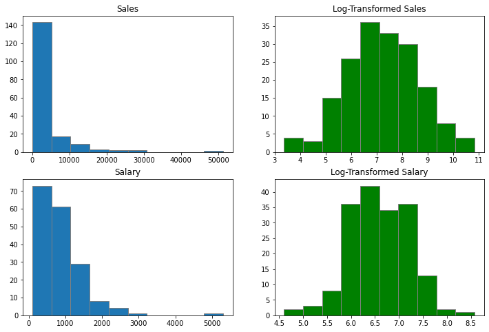

OLS Regression Results

| Dep. Variable: | lnsalary | R-squared: | 0.284 |
| --- | --- | --- | --- |
| Model: | OLS | Adj. R-squared: | 0.280 |
| Method: | Least Squares | F-statistic: | 69.45 |
| Date: | Wed, 16 Oct 2024 | Prob (F-statistic): | 2.22e-14 |
| Time: | 16:25:08 | Log-Likelihood: | -133.09 |
| No. Observations: | 177 | AIC: | 270.2 |
| Df Residuals: | 175 | BIC: | 276.5 |
| Df Model: | 1 |  |  |
| Covariance Type: | nonrobust |  |  |

|  | coef | std err | t | P>\|t\| | [0.025 | 0.975] |
| --- | --- | --- | --- | --- | --- | --- |
| Intercept | 4.9469 | 0.200 | 24.703 | 0.000 | 4.552 | 5.342 |
| lnsales | 0.2264 | 0.027 | 8.333 | 0.000 | 0.173 | 0.280 |

| Omnibus: | 12.470 | Durbin-Watson: | 2.090 |
| --- | --- | --- | --- |
| Prob(Omnibus): | 0.002 | Jarque-Bera (JB): | 33.002 |
| Skew: | 0.060 | Prob(JB): | 6.82e-08 |
| Kurtosis: | 5.112 | Cond. No. | 38.7 |

Notes:  
[1] Standard Errors assume that the covariance matrix of the errors is correctly specified.

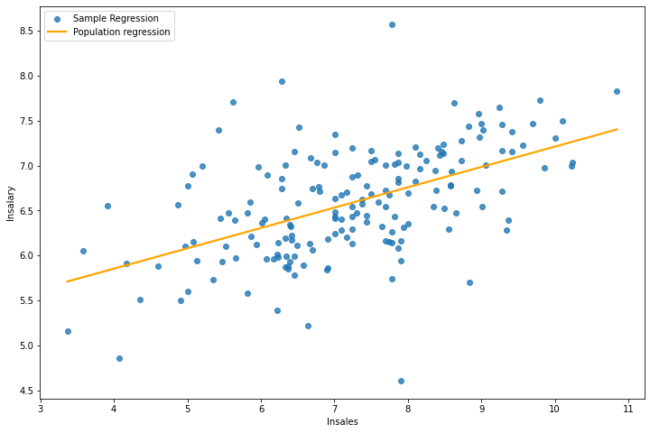

# Question 2

Use the dataset ATTEND for this exercise, and the handouts to work on these questions. Wooldridge data sets here: http://fmwww.bc.edu/ec-p/data/wooldridge/datasets.list.html

i. Generate a table that shows the minimum, maximum, and average values for the following variables in the attend dataset:  
Percent classes attended  
Cumulative GPA prior to term  
ACT score  
Using two different methods. Round off all calculations to 3 decimal points. (Refer to handout)

|  | atndrte | priGPA | ACT |
| --- | --- | --- | --- |
| mean | 81.71 | 2.587 | 22.51 |
| min | 6.25 | 0.857 | 13.00 |
| max | 100.00 | 3.930 | 32.00 |

|  | atndrte | priGPA | ACT |
| --- | --- | --- | --- |
| count | 680.000 | 680.000 | 680.000 |
| mean | 81.710 | 2.587 | 22.510 |
| std | 17.047 | 0.545 | 3.491 |
| min | 6.250 | 0.857 | 13.000 |
| 25% | 75.000 | 2.190 | 20.000 |
| 50% | 87.500 | 2.560 | 22.000 |
| 75% | 93.750 | 2.943 | 25.000 |
| max | 100.000 | 3.930 | 32.000 |

ii. Estimate the following model:

$$atndrte = \beta_0 + \beta_1 priGPA + \beta_2 ACT + u$$

Show results in an stargazer table. (Refer to output presentation handout)

|  | *Dependent variable:atndrte* |
| --- | --- |
|  | (1) |
| ACT | -1.717*** |
|  | (0.169) |
| Intercept | 75.700*** |
|  | (3.884) |
| priGPA | 17.261*** |
|  | (1.083) |
| Observations | 680 |
| R<sup>2</sup> | 0.291 |
| Adjusted R<sup>2</sup> | 0.288 |
| Residual Std. Error | 14.379 (df=677) |
| F Statistic | 138.651*** (df=2; 677) |
| Note: | *p<0.1; **p<0.05; ***p<0.01 |

iii. Calculate and print the average of predicted value of percent classes attended ( $\hat{atndrte}$ ) and the predicted value. Round to 5 decimal points and compare results. (Refer to week 5 module)

> Note that these two are different coding-wise. The first method is the mean of the prediction, and the second is the prediction of the mean

```
Model1
 Average predicted attendance rate is
 mean of yhat= 81.70956
Model1
 Predicted attendance rate for average GPA and ACT is
 yhat of mean x=  81.70956
```

iv. What is the predicted `atndrte` if `priGPA`= 3.65 and `ACT`= 20? What is the predicted difference in attendance rates between this and the the average $\hat{atndrte}$ above? (Refer to week 3 and 4 module)
In this case, do not use the `.predict()` function for your code. Instead, retrieve the coeffients and calculate the equation.
$$atndrte = \hat\beta_0 + \hat\beta_1 3.65 + \hat\beta_2 20 + u$$

```
yhat =  104.371
Difference =  22.661
```

v. Run two more models: one only for freshmen and another only for sophomores. Save the results in objects `mfre` and `msoph` respectively  
*Hint: the data argument now has a restriction*  
Freshmen : `attend['frosh']==1`  
Sophomores : `attend['soph']==1`

vi. Show your results in a table:

Create one table comparing the parameters from the three models and another table comparing $R^2$ and the number of observations. Label the results with all students "All", data with just freshmen "Freshmen", and data with just sophomores "Sophomore". Round all values to 4 decimal places. (Refer to week 3 module)

The table below compares $\beta's$

|  | All | Freshmen | Soph |
| --- | --- | --- | --- |
| Intercept | 75.700 | 76.507 | 74.887 |
| priGPA | 17.261 | 16.062 | 18.869 |
| ACT | -1.717 | -1.487 | -1.898 |

The table below compares the $R^2$ and observations for the models estimated. $\textbf{HINT:}$ If you are stuck, look up how to use the index options.

|  | All | Freshmen | Soph |
| --- | --- | --- | --- |
| R2 | 0.291 | 0.286 | 0.320 |
| obs | 680.000 | 158.000 | 392.000 |

vii. Calculate the correlation between the residuals and the `priGPA` for the first model. This is similar to how we showed that mean of residuals is equal to zero (Refer to week 3 and module).

```
Corr GPA and residuals:
 0.0
```

vi. Present all results form the three models in an stargazer table Change the order of the covariates and add name to the columns

|  | *Dependent variable:atndrte* |  |  |
| --- | --- | --- | --- |
|  | All | Freshmen | Sophomore |
|  | (1) | (2) | (3) |
| Intercept | 75.700*** | 76.507*** | 74.887*** |
|  | (3.884) | (8.679) | (5.113) |
| priGPA | 17.261*** | 16.062*** | 18.869*** |
|  | (1.083) | (2.362) | (1.440) |
| ACT | -1.717*** | -1.487*** | -1.898*** |
|  | (0.169) | (0.331) | (0.227) |
| Observations | 680 | 158 | 392 |
| R<sup>2</sup> | 0.291 | 0.286 | 0.320 |
| Adjusted R<sup>2</sup> | 0.288 | 0.277 | 0.316 |
| Residual Std. Error | 14.379 (df=677) | 14.029 (df=155) | 14.157 (df=389) |
| F Statistic | 138.651*** (df=2; 677) | 31.106*** (df=2; 155) | 91.510*** (df=2; 389) |
| Note: | *p<0.1; **p<0.05; ***p<0.01 |  |  |

# From Computer Exercise 10

Use the data in Wooldridge's HTV to answer this question. The data set includes information on wages, education, parents’ education, and several other variables for 1,230 working men in 1991.

i. Investigate some descriptive statistics

- What is the range of the `educ` variable in the sample?

```
count    1230.000000
mean       13.037398
std         2.354346
min         6.000000
25%        12.000000
50%        12.000000
75%        15.000000
max        20.000000
Name: educ, dtype: float64
```

- What percentage of men completed twelveth grade but no higher grade?

  > Hint: use a logical expression and calculate the mean
- Do the men or their parents have, on average, higher levels of education?

```
Percentage of men with HS=  0.416
```

|  | Averages |
| --- | --- |
| educ | 13.037 |
| motheduc | 12.178 |
| fatheduc | 12.447 |

ii. Estimate the regression model $$educ = \beta_0 + \beta_1motheduc + \beta_2fatheduc + u$$ by OLS and report the results in the usual form.

How much sample variation in `educ` is explained by parents’ education? Think about the interpretation of the coefficient on `motheduc`.

OLS Regression Results

| Dep. Variable: | educ | R-squared: | 0.249 |
| --- | --- | --- | --- |
| Model: | OLS | Adj. R-squared: | 0.248 |
| Method: | Least Squares | F-statistic: | 203.7 |
| Date: | Wed, 16 Oct 2024 | Prob (F-statistic): | 4.13e-77 |
| Time: | 16:49:21 | Log-Likelihood: | -2621.7 |
| No. Observations: | 1230 | AIC: | 5249. |
| Df Residuals: | 1227 | BIC: | 5265. |
| Df Model: | 2 |  |  |
| Covariance Type: | nonrobust |  |  |

|  | coef | std err | t | P>\|t\| | [0.025 | 0.975] |
| --- | --- | --- | --- | --- | --- | --- |
| Intercept | 6.9644 | 0.320 | 21.776 | 0.000 | 6.337 | 7.592 |
| motheduc | 0.3042 | 0.032 | 9.528 | 0.000 | 0.242 | 0.367 |
| fatheduc | 0.1903 | 0.022 | 8.539 | 0.000 | 0.147 | 0.234 |

| Omnibus: | 60.519 | Durbin-Watson: | 1.748 |
| --- | --- | --- | --- |
| Prob(Omnibus): | 0.000 | Jarque-Bera (JB): | 82.103 |
| Skew: | 0.455 | Prob(JB): | 1.48e-18 |
| Kurtosis: | 3.879 | Cond. No. | 98.0 |

Notes:  
[1] Standard Errors assume that the covariance matrix of the errors is correctly specified.

iii. Add the variable `abil` (a measure of cognitive ability) to the regression from part (ii), and report the results in equation form. Does “ability” help to explain variations in education, even after controlling for parents’ education? Explain.

OLS Regression Results

| Dep. Variable: | educ | R-squared: | 0.428 |
| --- | --- | --- | --- |
| Model: | OLS | Adj. R-squared: | 0.426 |
| Method: | Least Squares | F-statistic: | 305.2 |
| Date: | Wed, 16 Oct 2024 | Prob (F-statistic): | 5.95e-148 |
| Time: | 16:49:23 | Log-Likelihood: | -2455.0 |
| No. Observations: | 1230 | AIC: | 4918. |
| Df Residuals: | 1226 | BIC: | 4938. |
| Df Model: | 3 |  |  |
| Covariance Type: | nonrobust |  |  |

|  | coef | std err | t | P>\|t\| | [0.025 | 0.975] |
| --- | --- | --- | --- | --- | --- | --- |
| Intercept | 8.4487 | 0.290 | 29.180 | 0.000 | 7.881 | 9.017 |
| motheduc | 0.1891 | 0.029 | 6.635 | 0.000 | 0.133 | 0.245 |
| fatheduc | 0.1111 | 0.020 | 5.586 | 0.000 | 0.072 | 0.150 |
| abil | 0.5025 | 0.026 | 19.538 | 0.000 | 0.452 | 0.553 |

| Omnibus: | 52.055 | Durbin-Watson: | 1.821 |
| --- | --- | --- | --- |
| Prob(Omnibus): | 0.000 | Jarque-Bera (JB): | 61.086 |
| Skew: | 0.465 | Prob(JB): | 5.44e-14 |
| Kurtosis: | 3.570 | Cond. No. | 102. |

Notes:  
[1] Standard Errors assume that the covariance matrix of the errors is correctly specified.

iv. Now estimate an equation where `abil` appears in quadratic form

OLS Regression Results

| Dep. Variable: | educ | R-squared: | 0.444 |
| --- | --- | --- | --- |
| Model: | OLS | Adj. R-squared: | 0.443 |
| Method: | Least Squares | F-statistic: | 244.9 |
| Date: | Wed, 16 Oct 2024 | Prob (F-statistic): | 1.34e-154 |
| Time: | 16:49:31 | Log-Likelihood: | -2436.6 |
| No. Observations: | 1230 | AIC: | 4883. |
| Df Residuals: | 1225 | BIC: | 4909. |
| Df Model: | 4 |  |  |
| Covariance Type: | nonrobust |  |  |

|  | coef | std err | t | P>\|t\| | [0.025 | 0.975] |
| --- | --- | --- | --- | --- | --- | --- |
| Intercept | 8.2402 | 0.287 | 28.671 | 0.000 | 7.676 | 8.804 |
| motheduc | 0.1901 | 0.028 | 6.767 | 0.000 | 0.135 | 0.245 |
| fatheduc | 0.1089 | 0.020 | 5.558 | 0.000 | 0.070 | 0.147 |
| abil | 0.4015 | 0.030 | 13.255 | 0.000 | 0.342 | 0.461 |
| np.power(abil, 2) | 0.0506 | 0.008 | 6.093 | 0.000 | 0.034 | 0.067 |

| Omnibus: | 45.933 | Durbin-Watson: | 1.820 |
| --- | --- | --- | --- |
| Prob(Omnibus): | 0.000 | Jarque-Bera (JB): | 56.769 |
| Skew: | 0.404 | Prob(JB): | 4.71e-13 |
| Kurtosis: | 3.674 | Cond. No. | 115. |

Notes:  
[1] Standard Errors assume that the covariance matrix of the errors is correctly specified.

v. Use the estimates in part (iv) to graph the relationship between the predicted `education` and `abil`. Set `motheduc` and `fatheduc` at their average values in the sample, 12.18 and 12.45, respectively. See handout for more. (Refer to week 4 module)

```
Intercept            8.240226
motheduc             0.190126
fatheduc             0.108939
abil                 0.401462
np.power(abil, 2)    0.050599
dtype: float64
```

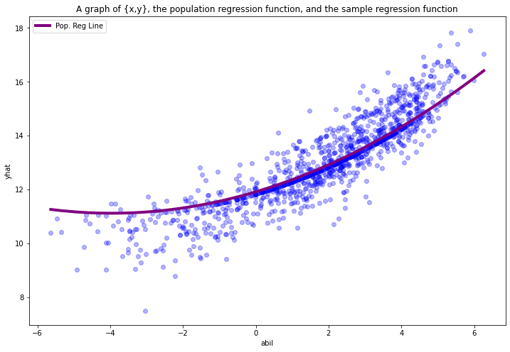

ECON320 Python Programming Laboratory

Professor *Paloma Lopez de mesa Moyano*

*paloma.moyano@emory.edu*

Department of Economics

Emory University